# hw1_lm

Anna Roser

January 22, 2019

```r
knitr::opts_chunk$set(echo = TRUE)
library(fitdistrplus)
library(grDevices)
library(knitr)
```

## Question 1: Math and LSD

### A) What level of LSD tissue concentration do you need to ensure a test score of >85%?

Solve 85 = 89.12-9.01x

You need a LSD concentration of 0.45g to get >85% score

### B)How well does LSD tissue concentration predict test performance?

For every one gram of LSD ingested, the participants score drops by 9.01%

### C)Why might the normal distribution be inappropriate to model these data?

Because we have a small sample size and high variance in the data (6.05)

```r
math<-read.csv("math_scores.csv")
head(math)
```

```
##   LSD_concentration MATH_score
## 1              1.17      78.93
## 2              2.97      58.20
## 3              3.26      67.47
## 4              4.69      37.47
## 5              5.83      45.65
## 6              6.00      32.92
```

```r
str(math)
```

```
## 'data.frame':    7 obs. of  2 variables:
##  $ LSD_concentration: num  1.17 2.97 3.26 4.69 5.83 6 6.41
##  $ MATH_score       : num  78.9 58.2 67.5 37.5 45.6 ...
```

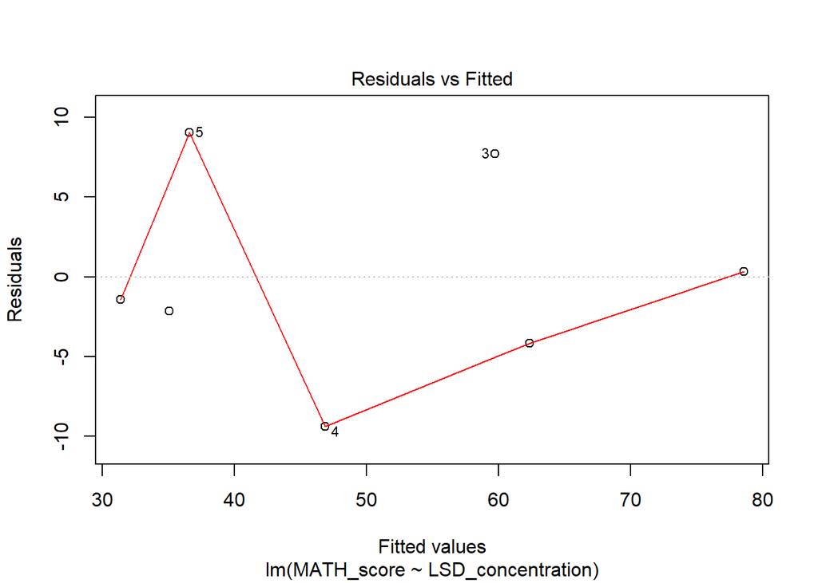

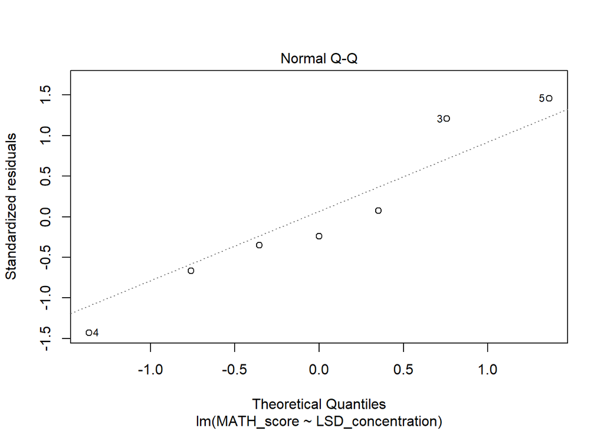

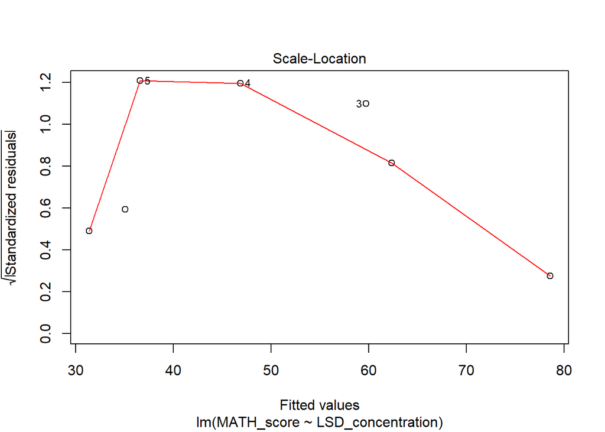

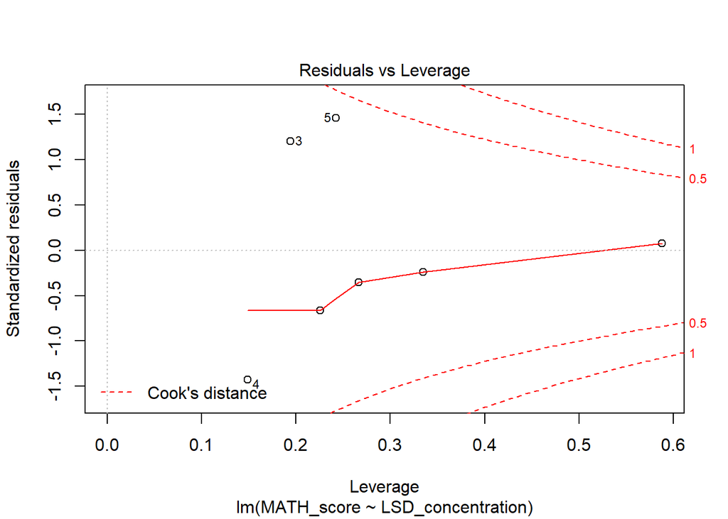

```r
#make a model
modmath<-lm(MATH_score~LSD_concentration, data = math)
plot(modmath)
```

```r
#lm is a function to fit linear models, regression, single stratum analysis of variance and analysis of covariance
coef(modmath)
```

```
##       (Intercept) LSD_concentration
##         89.123874         -9.009466
```

### a) Make a scatterplot

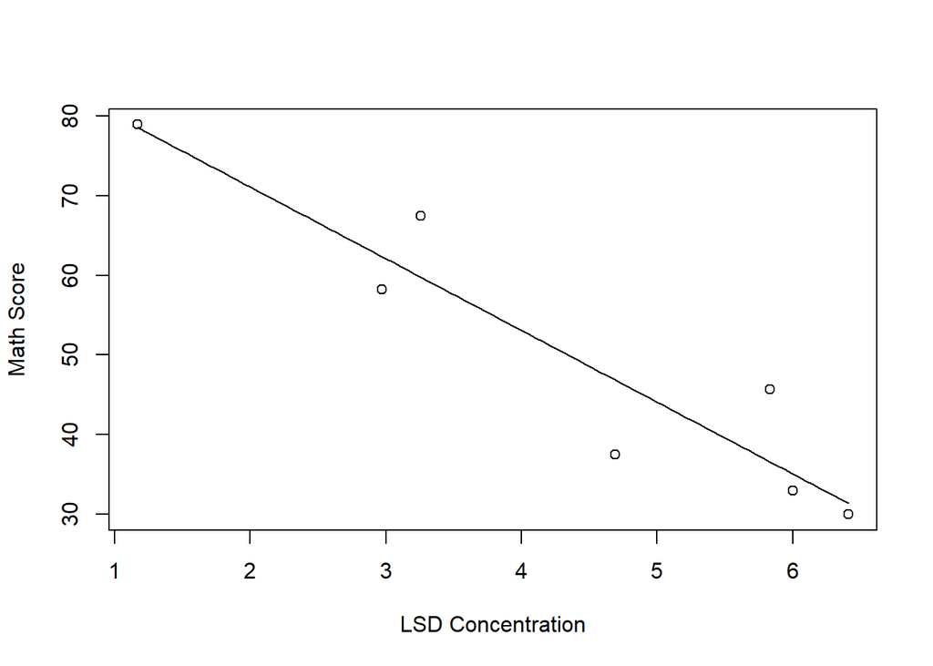

```r
plot(math$MATH_score~math$LSD_concentration, xlab = "LSD Concentration", ylab = "Math Score")
curve(89.12-9.01*x, add = T)
```

### b)parameter estimates and 95%CI

```r
coef(modmath)
```

```
##       (Intercept) LSD_concentration
##         89.123874         -9.009466
```

```r
confint(modmath)
```

```
##                       2.5 %     97.5 %
## (Intercept)        71.00758 107.240169
## LSD_concentration -12.87325  -5.145685
```

### c)calculate R2 or RMSE

```r
r2<-function(y_hat, y) {
  TSS<-sum((y-mean(y))^2)
  RSS<-sum((y-y_hat)^2)
  return(1-RSS/TSS)
}

y_hat<-89.12-9.01*math$LSD_concentration

r2(y_hat, math$MATH_score)
```

```
## [1] 0.8778348
```

```r
rmse=function(y_hat,y){
  return(sqrt(mean((y-y_hat)^2)))
}

rmse(y_hat, math$MATH_score)
```

```
## [1] 6.022358
```

## Question 2: POM miracle food

### With the least squares output in mind, do you agree or disagree with the miracle claim?

```r
food<-read.csv("miracle_food.csv")
head(food)
```

```
##   Weight_loss pomegranate
## 1       -0.89           2
## 2        6.31           2
## 3      -30.21           3
## 4       -6.28           7
## 5       11.38           4
## 6        1.67           2
```

```r
str(food)
```

```
## 'data.frame':    1000 obs. of  2 variables:
##  $ Weight_loss: num  -0.89 6.31 -30.21 -6.28 11.38 ...
##  $ pomegranate: int  2 2 3 7 4 2 3 3 5 5 ...
```

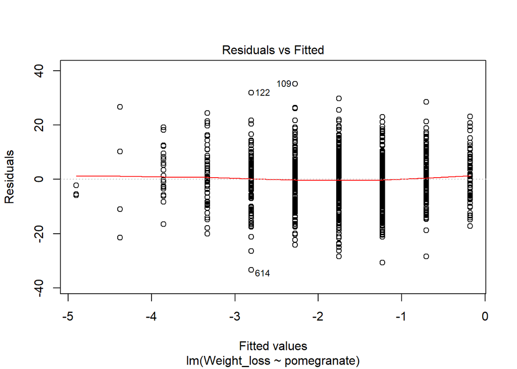

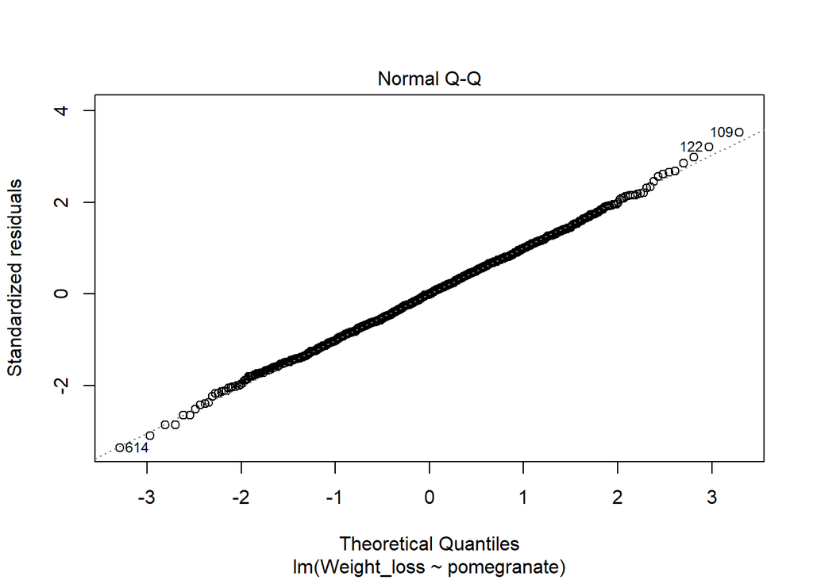

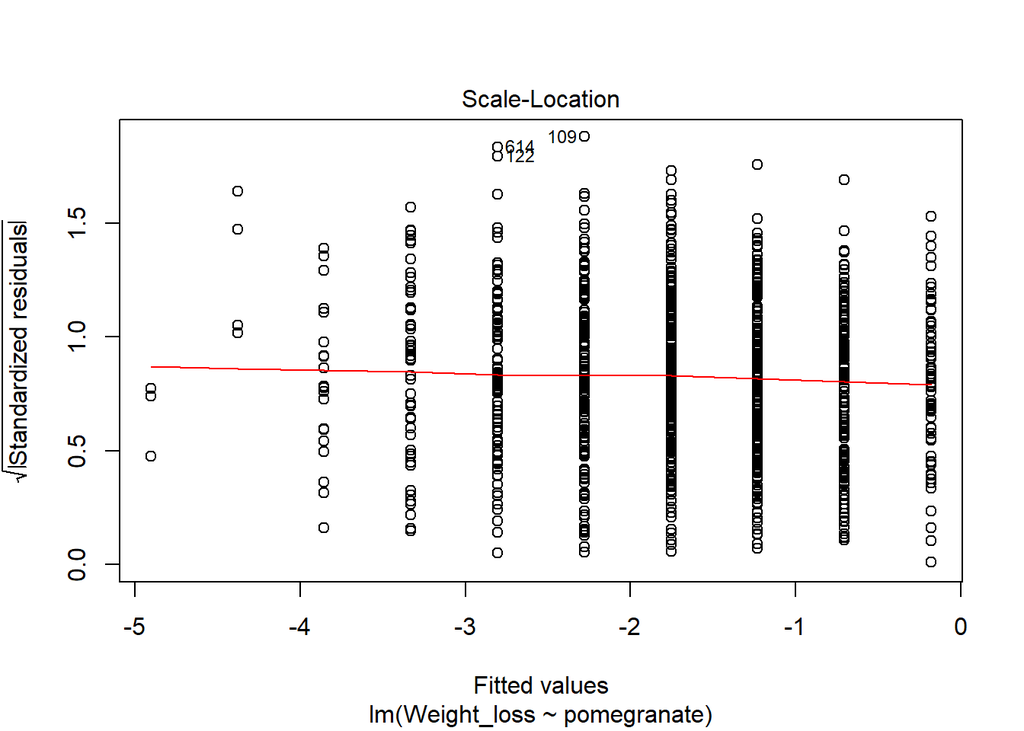

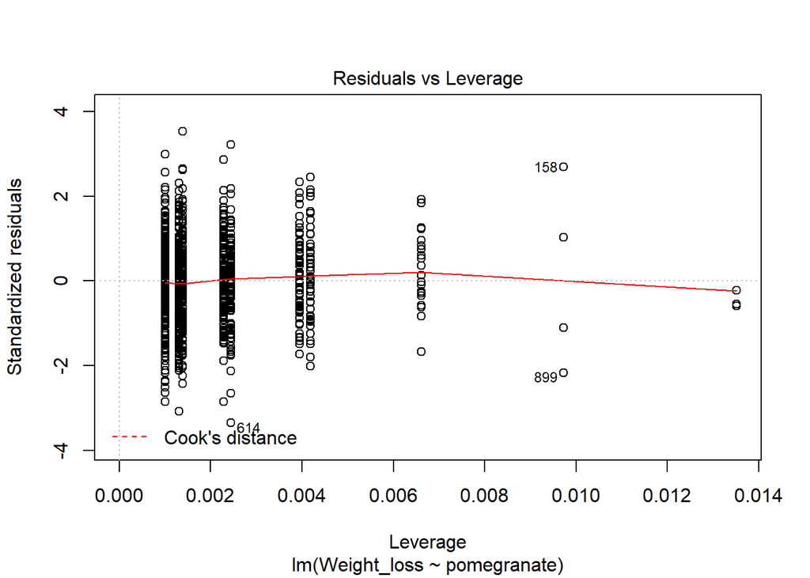

```r
#make a model
modfood<-lm(Weight_loss~pomegranate, data = food)
plot(modfood)
```

```r
#lm is a function to fit linear models, regression, single stratum analysis of variance and analysis of covariance
```

### a)Scatterplot

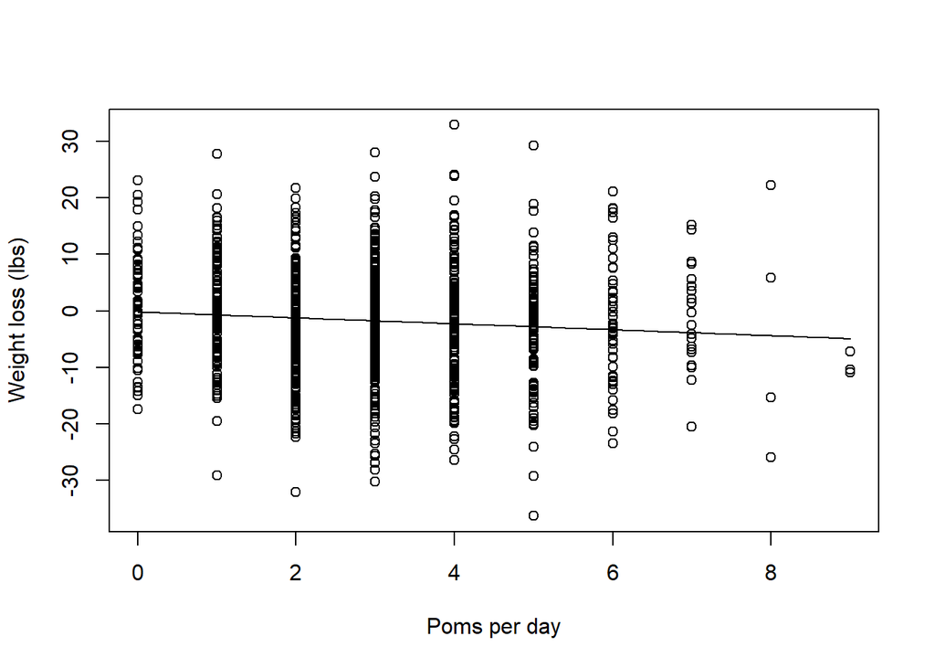

```r
plot(food$Weight_loss~food$pomegranate, xlab = "Poms per day", ylab = "Weight loss (lbs)")
curve(-0.178-0.525*x, add = T)
```

### b)parameter estimates and CI-95

```r
coef(modfood)
```

```
## (Intercept) pomegranate
##  -0.1789802  -0.5251053
```

```r
confint(modfood)
```

```
##                 2.5 %     97.5 %
## (Intercept) -1.408937  1.0509767
## pomegranate -0.886420 -0.1637906
```

### c)R2 and RMSE

```r
y_hat1<- -0.178-0.525*food$pomegranate

r2(y_hat1, food$Weight_loss)
```

```
## [1] 0.008083795
```

```r
rmse(y_hat1, food$Weight_loss)
```

```
## [1] 9.961044
```

## Question 3: Mean Absolute Error

### A) Translate the mathematical equation for MAE into a function in R.

```r
MAE<-function(y,x) {
 temp_lm<-lm(y~x)
 int <- coef(temp_lm)[1]
 slope <- coef(temp_lm)[2]
  y_hat<-int+slope*x
  n <- length(y)
  arss<-sum(abs(y-y_hat), na.rm = T)/n
  return(arss)
}
```

### B) Compare RMSE, R2, and MAE for the linear models in questions 1 and 2. How do these metrics of model fit differ?

R2 is the coefficient of determination which measures the proportion of total variation explained by the model. RMSE is the squared difference between values estimated by the model and observed values–it is a measure of error (it is scale dependent and effected by large numbers).Mean Absolute Error is the average absolute difference between predicted values and observed, true values and is reported in the same scale as the data was measured.

LSD and Math: R2: 0.877 RMSE: 6.022 MAE: 4.89

Poms and Weight: R2: 0.008 RMSE: 9.96 MAE: 7.98

Side note from Josh: if RMSE ~= MAE then you have many, small errors. If RMSE ~= MAE^2 then you have a few large errors

```r
#MAE for food and math
MAE(food$Weight_loss,food$pomegranate)
```

```
## [1] 7.981461
```

```r
MAE(math$MATH_score,math$LSD_concentration)
```

```
## [1] 4.890144
```